# Day 20: Hierarchical Clustering — In-Class Activity (Solutions)

What’s inside the elite cluster?

Instructor

```r
data(College)
colleges <- College %>%
  mutate(college = rownames(College),          # the names are row names; make them a column
         accept_rate = Accept / Apps) %>%      # share of applicants admitted
  select(college, Private, accept_rate, Top10perc, F.Undergrad, Outstate,
         S.F.Ratio, perc.alumni, Expend, Grad.Rate)

claremont <- c("Claremont McKenna College", "Harvey Mudd College",
               "Pitzer College", "Scripps College")
liberal_arts <- c("Amherst College", "Williams College", "Wellesley College",
                  "Bowdoin College", "Carleton College", "Davidson College",
                  "Reed College", "Occidental College", "Grinnell College",
                  "Macalester College", "Vassar College", "Barnard College",
                  "Bryn Mawr College", "Smith College")
universities <- c("Harvard University", "Yale University", "Princeton University",
                  "Massachusetts Institute of Technology", "Duke University",
                  "Columbia University", "Brown University", "Dartmouth College",
                  "University of Pennsylvania", "Northwestern University",
                  "University of California at Berkeley",
                  "University of Michigan at Ann Arbor")
picked <- c(claremont, liberal_arts, universities)

# Day 19: standardize the eight columns over all 777 colleges
Z <- scale(colleges %>% select(-college, -Private))
rownames(Z) <- colleges$college                # keep the names on the rows

# Keep the 30 picked colleges (all in Day 19's elite cluster)
elite <- colleges %>% filter(college %in% picked)
Z_elite <- Z[elite$college, ]
nrow(Z_elite)
```

```
## [1] 30
```

## Part 1: The Dendrogram

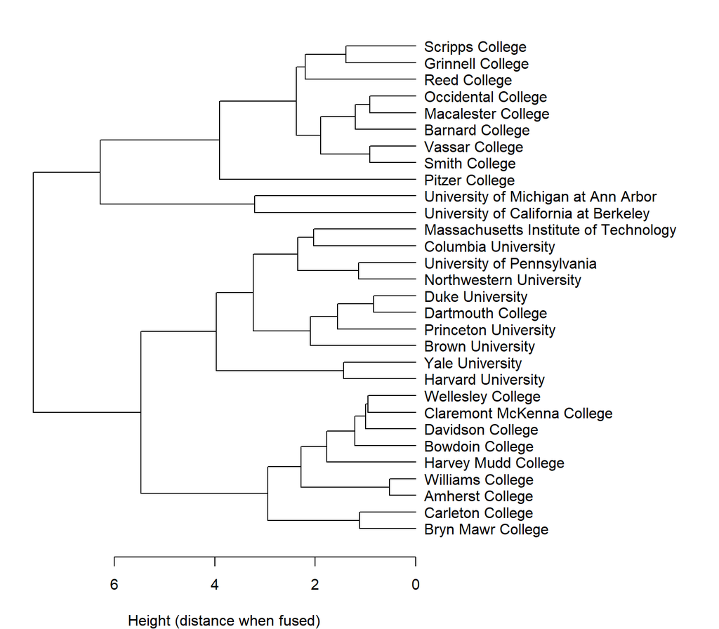

```r
hc <- hclust(dist(Z_elite))

par(mar = c(4, 1, 1, 16))                     # room on the right for the names
plot(as.dendrogram(hc), horiz = TRUE, xlab = "Height (distance when fused)")
```

CMC fuses first with **Wellesley College**, at height 0.95: on these eight columns, its closest match among the 30. Harvey Mudd joins at 1.77 a group of 4: Bowdoin College, Davidson College, Claremont McKenna College, Wellesley College.

CMC’s and Pitzer’s branches first meet at **7.61**, the very top of the tree. CMC’s and Harvard’s meet lower, at **5.47**. So **Harvard** is more similar to CMC than Pitzer is, on these eight columns. Pitzer has far fewer students from the top 10% of their high school class (37% vs CMC’s 71%) and far less alumni giving (11% vs 52%). (Where the names sit in the list doesn’t matter; only the height where the branches meet does.)

## Part 2: Cutting the Tree

```r
elite <- elite %>%
  mutate(k2 = cutree(hc, k = 2),
         k3 = cutree(hc, k = 3),
         k4 = cutree(hc, k = 4))

elite %>% count(k2, k3)                       # how the 2 clusters become 3
```

```
##   k2 k3  n
## 1  1  1 19
## 2  2  2  9
## 3  2  3  2
```

```r
elite %>% count(k3, k4)                       # how the 3 clusters become 4
```

```
##   k3 k4  n
## 1  1  1  9
## 2  1  3 10
## 3  2  2  9
## 4  3  4  2
```

```r
elite %>%
  group_by(k4) %>%                           # one row per cluster
  summarise(colleges = n(), across(accept_rate:Grad.Rate, mean),
            share_private = mean(Private == "Yes"))
```

```
## # A tibble: 4 × 11
##      k4 colleges accept_rate Top10perc F.Undergrad Outstate S.F.Ratio
##   <int>    <int>       <dbl>     <dbl>       <dbl>    <dbl>     <dbl>
## 1     1        9       0.404      78.8       1485.   18416.     10.2
## 2     2        9       0.602      51.7       1558.   17634.     10.3
## 3     3       10       0.281      88.3       5688    18804.      7.05
## 4     4        2       0.545      80.5      20788.   13690      13.6
## # ℹ 4 more variables: perc.alumni <dbl>, Expend <dbl>, Grad.Rate <dbl>,
## #   share_private <dbl>
```

```r
elite %>% arrange(k4) %>% select(college, k4)  # who is in each cluster
```

```
##                                                                     college k4
## Amherst College                                             Amherst College  1
## Bowdoin College                                             Bowdoin College  1
## Bryn Mawr College                                         Bryn Mawr College  1
## Carleton College                                           Carleton College  1
## Claremont McKenna College                         Claremont McKenna College  1
## Davidson College                                           Davidson College  1
## Harvey Mudd College                                     Harvey Mudd College  1
## Wellesley College                                         Wellesley College  1
## Williams College                                           Williams College  1
## Barnard College                                             Barnard College  2
## Grinnell College                                           Grinnell College  2
## Macalester College                                       Macalester College  2
## Occidental College                                       Occidental College  2
## Pitzer College                                               Pitzer College  2
## Reed College                                                   Reed College  2
## Scripps College                                             Scripps College  2
## Smith College                                                 Smith College  2
## Vassar College                                               Vassar College  2
## Brown University                                           Brown University  3
## Columbia University                                     Columbia University  3
## Dartmouth College                                         Dartmouth College  3
## Duke University                                             Duke University  3
## Harvard University                                       Harvard University  3
## Massachusetts Institute of Technology Massachusetts Institute of Technology  3
## Northwestern University                             Northwestern University  3
## Princeton University                                   Princeton University  3
## University of Pennsylvania                       University of Pennsylvania  3
## Yale University                                             Yale University  3
## University of California at Berkeley   University of California at Berkeley  4
## University of Michigan at Ann Arbor     University of Michigan at Ann Arbor  4
```

**One cluster splits each time** (checked: every cut splits exactly one cluster). The tree’s clusters are nested, unlike Day 19’s k-means. The first split is not liberal arts colleges vs universities: it puts the most selective liberal arts colleges together with the private universities.

The four clusters:

- **Top liberal arts colleges** (9): CMC, Harvey Mudd, Amherst, Williams, …; admit 40%, 79% from the top 10%, about 1,485 undergraduates, and 94% graduate.
- **Other liberal arts colleges** (9): Pitzer, Scripps, Reed, Vassar, …; admit 60%, 52% from the top 10%, 80% graduate.
- **Top private universities** (10): Harvard, Yale, Princeton, MIT, …; admit 28%, about 5,688 undergraduates, and spend $30,000 per student, about half again as much as the top liberal arts colleges.
- **Public flagships** (2): University of California at Berkeley and University of Michigan at Ann Arbor.

The Claremont Colleges split in two: **CMC and Harvey Mudd** are in the top liberal arts cluster, **Pitzer and Scripps** in the other liberal arts cluster.

The public flagships are the cluster of two. They are far bigger (about 20,788 undergraduates on average), they are the only public colleges (0% private), out-of-state tuition is lower ($13,700), and alumni give much less (18%).

## Part 3: Linkage

*Prediction:* single linkage, because it fuses two groups as soon as their **closest** pair is close, so groups keep growing by chaining one neighbor at a time.

```r
elite <- elite %>%
  mutate(complete = cutree(hclust(dist(Z_elite), method = "complete"), k = 4),
         average  = cutree(hclust(dist(Z_elite), method = "average"), k = 4),
         single   = cutree(hclust(dist(Z_elite), method = "single"), k = 4))

elite %>% count(complete) %>% arrange(desc(n))  # cluster sizes, biggest first
```

```
##   complete  n
## 1        3 10
## 2        1  9
## 3        2  9
## 4        4  2
```

```r
elite %>% count(average) %>% arrange(desc(n))
```

```
##   average  n
## 1       1 19
## 2       2  9
## 3       3  1
## 4       4  1
```

```r
elite %>% count(single) %>% arrange(desc(n))
```

```
##   single  n
## 1      1 27
## 2      2  1
## 3      3  1
## 4      4  1
```

```r
elite %>%
  group_by(single) %>%
  filter(n() == 1) %>%                          # the clusters of one
  select(college, single)
```

```
## # A tibble: 3 × 2
## # Groups:   single [3]
##   college                               single
##   <chr>                                  <int>
## 1 Massachusetts Institute of Technology      2
## 2 University of California at Berkeley       3
## 3 University of Michigan at Ann Arbor        4
```

**Complete** linkage is the most balanced (10 / 9 / 9 / 2), then **average** (19 / 9 / 1 / 1). **Single** linkage is the least balanced: 27 colleges in one cluster and Massachusetts Institute of Technology, University of California at Berkeley, University of Michigan at Ann Arbor each on its own. So the prediction was right.

Single linkage fuses two groups as soon as **any** pair of their colleges is close. Most of the 30 colleges are linked by a chain of close neighbors, so they all join early. The colleges left on their own are the ones that are far from **every** other college: Berkeley’s and Michigan’s nearest neighbor is each other, at 3.21 (they are huge), and MIT’s is 2.03 away (it spends 4.57 SDs above the average college per student). That’s useful for spotting outliers, not for peer groups. For peer groups, complete (or average) linkage, which gives groups of similar sizes.

## Bonus

### Bonus 1: Where to cut?

```r
tail(hc$height, 8)                     # the last 8 fusions
```

```
## [1] 2.944167 3.207593 3.236415 3.900234 3.964648 5.470183 6.277572 7.611135
```

```r
elite %>% count(h7 = cutree(hc, h = 7))  # cut at height 7
```

```
##   h7  n
## 1  1 19
## 2  2 11
```

A cut at height 7 gives **2 clusters**: 1 fusion happens above 7 (at 7.61), and undoing each one adds a cluster. The biggest gap is between the fusions at 5.47 and 3.96; a cut inside it gives **4 clusters**, the four from Part 2. Here the gap rule and the four clusters agree; in general where to cut is a judgment call, like the elbow on Day 19.

### Bonus 2: Standardize within the 30

```r
Z_within <- scale(elite %>% select(accept_rate:Grad.Rate))   # SDs over the 30 only
rownames(Z_within) <- elite$college
hc_within <- hclust(dist(Z_within))
elite <- elite %>% mutate(within4 = cutree(hc_within, k = 4))

elite %>% filter(college %in% claremont) %>% select(college, k4, within4)
```

```
##                                             college k4 within4
## Claremont McKenna College Claremont McKenna College  1       3
## Harvey Mudd College             Harvey Mudd College  1       1
## Pitzer College                       Pitzer College  2       2
## Scripps College                     Scripps College  2       2
```

```r
elite %>% arrange(within4) %>% select(college, within4)
```

```
##                                                                     college
## Amherst College                                             Amherst College
## Brown University                                           Brown University
## Columbia University                                     Columbia University
## Dartmouth College                                         Dartmouth College
## Duke University                                             Duke University
## Harvard University                                       Harvard University
## Harvey Mudd College                                     Harvey Mudd College
## Massachusetts Institute of Technology Massachusetts Institute of Technology
## Northwestern University                             Northwestern University
## Princeton University                                   Princeton University
## University of Pennsylvania                       University of Pennsylvania
## Williams College                                           Williams College
## Yale University                                             Yale University
## Barnard College                                             Barnard College
## Grinnell College                                           Grinnell College
## Macalester College                                       Macalester College
## Occidental College                                       Occidental College
## Pitzer College                                               Pitzer College
## Reed College                                                   Reed College
## Scripps College                                             Scripps College
## Smith College                                                 Smith College
## Vassar College                                               Vassar College
## Bowdoin College                                             Bowdoin College
## Bryn Mawr College                                         Bryn Mawr College
## Carleton College                                           Carleton College
## Claremont McKenna College                         Claremont McKenna College
## Davidson College                                           Davidson College
## Wellesley College                                         Wellesley College
## University of California at Berkeley   University of California at Berkeley
## University of Michigan at Ann Arbor     University of Michigan at Ann Arbor
##                                       within4
## Amherst College                             1
## Brown University                            1
## Columbia University                         1
## Dartmouth College                           1
## Duke University                             1
## Harvard University                          1
## Harvey Mudd College                         1
## Massachusetts Institute of Technology       1
## Northwestern University                     1
## Princeton University                        1
## University of Pennsylvania                  1
## Williams College                            1
## Yale University                             1
## Barnard College                             2
## Grinnell College                            2
## Macalester College                          2
## Occidental College                          2
## Pitzer College                              2
## Reed College                                2
## Scripps College                             2
## Smith College                               2
## Vassar College                              2
## Bowdoin College                             3
## Bryn Mawr College                           3
## Carleton College                            3
## Claremont McKenna College                   3
## Davidson College                            3
## Wellesley College                           3
## University of California at Berkeley        4
## University of Michigan at Ann Arbor         4
```

```r
as_tibble(Z_elite) %>% summarise(across(everything(), sd))   # spread among the 30, in all-777 SDs
```

```
## # A tibble: 1 × 8
##   accept_rate Top10perc F.Undergrad Outstate S.F.Ratio perc.alumni Expend
##         <dbl>     <dbl>       <dbl>    <dbl>     <dbl>       <dbl>  <dbl>
## 1        1.13     0.957        1.04    0.449     0.619        1.10   1.35
## # ℹ 1 more variable: Grad.Rate <dbl>
```

Now the top liberal arts cluster splits: Amherst College, Harvey Mudd College, Williams College join the top private universities (a cluster of 13), while CMC stays with Bowdoin College, Bryn Mawr College, Carleton College, Davidson College, Wellesley College. Pitzer and Scripps don’t move.

Standardizing over 777 colleges measures each column in SDs of **all** colleges; over 30 it measures in SDs of these 30, which are much more alike on some columns. Out-of-state tuition, for example, varies among the 30 only 0.45 as much as among all 777, so after standardizing within the 30, a tuition difference counts about 2.2 times as much, and the tree changes. The choice of which rows to standardize over is part of what “similar” means.

### Bonus 3: All 777 colleges

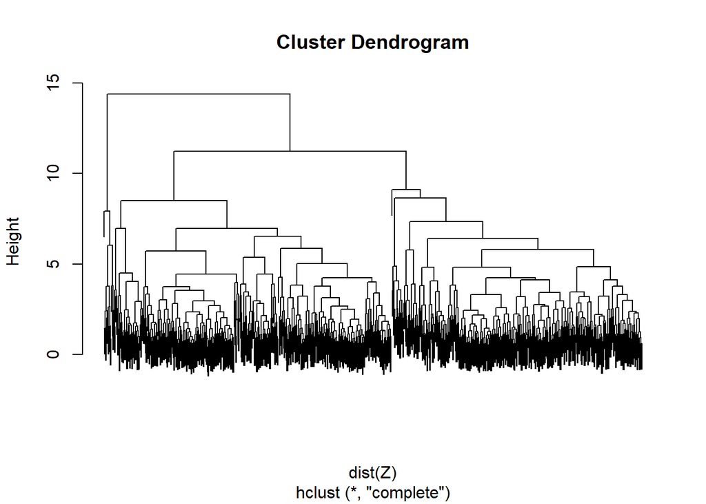

```r
plot(hclust(dist(Z)), labels = FALSE)
```

Without names you can’t look up colleges, but you can still see the shape: how many large branches there are, where the big gaps between fusion heights are (where to cut), and small branches joining very high up (outliers). With hundreds of rows the dendrogram stops being something you read name by name. K-means is the better pick for many rows (it’s faster and doesn’t need every pair of distances) or when you already know K; hierarchical clustering when the rows are few enough to read the tree, or you want nested clusters at several levels.